# Q3

```python
from keras.models import Sequential
from keras.layers import Dense
import numpy as np
import keras
import numpy as np
import matplotlib.pyplot as plt
```

```python
# 1. Create a model with 1 input layer, 1 hidden layer with 64 neurons and 1 output layer.
model = Sequential()
model.add(Dense(64, input_dim=1, activation='relu'))
model.add(Dense(1, activation='linear'))

# 2. Compile the model with mean squared error loss function and adam optimizer.
model.compile(loss='mean_squared_error', optimizer='adam')
X_train = np.random.uniform(low=-np.pi, high=np.pi, size=(1000, 1))
y_train = np.sin(X_train)
model.fit(X_train, y_train, epochs=500, batch_size=32, verbose=0)
```

```
Metal device set to: Apple M1 Pro
```

[output not shown]

```
<keras.callbacks.History at 0x16794fb20>
```

The model architecture consists of two dense layers, where the first layer has 64 nodes and uses the ReLU activation function, while the second layer has one node and uses the linear activation function. The input layer takes an input of one dimension specified by the input_dim parameter. The model is designed to predict the output of a regression problem, so the loss function used is the mean squared error, which is optimized using the Adam optimizer.

The training data is randomly generated with 1000 data points, where each point is a number between -π and +π. The target output is the sine function of each input point. The model is trained for 500 epochs with a batch size of 32, and the training progress updates are suppressed with a verbose level of 0.

Overall, this model design and choice of parameters seem appropriate for the given regression problem, and the use of the Adam optimizer and ReLU activation function can help speed up the training process and improve the model's accuracy.

The choice of the activation function for the first layer, ReLU, is a common choice for hidden layers in neural networks. ReLU has been shown to be effective in preventing vanishing gradients and allows the model to learn non-linear relationships between the input and output.

The choice of the activation function for the output layer, linear, is appropriate for regression problems where the output is a continuous value rather than a categorical value.

The choice of the loss function, mean squared error, is also appropriate for regression problems where the goal is to minimize the difference between the predicted and actual values. The Adam optimizer is a popular algorithm for gradient descent optimization and has been shown to converge faster than traditional stochastic gradient descent.

The choice of the size of the dataset, 1000 data points, and the range of values, between -π and +π, was chosen to provide a diverse range of input values and to allow the model to learn the sine function over a wide range of inputs.

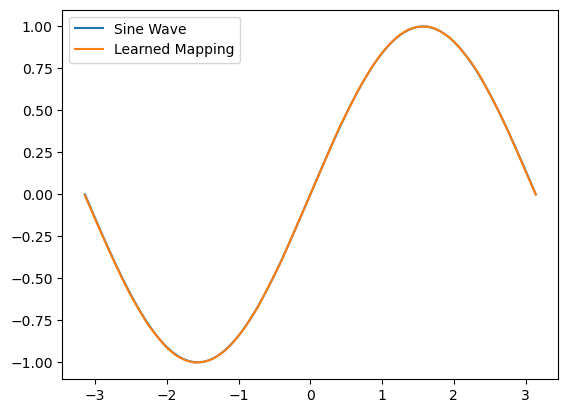

```python
# 3. Plot the sine wave and the learned mapping.
X = np.linspace(-np.pi, np.pi, 100)
y = np.sin(X)

y_pred = model.predict(X)

plt.plot(X, y, label='Sine Wave')
plt.plot(X, y_pred, label='Learned Mapping')
plt.legend()
plt.show()
```